# Matplotlib General Concepts

## Giới thiệu về Matplotlib

[figure not shown]

### Matplotlib

Matploblib là một thư viện trực quan hoá dữ liệu phổ biến trong Python. Nó có thể vẽ được nhiều loại đồ thị khác nhau, và rất hữu ích khi làm việc cùng với NumPy.

Hướng dẫn này nhằm giúp các bạn nhanh chóng cách sử dụng được các chức năng cơ bản của Matplotlib.

#### 1. Hướng dẫn cài đặt

- Nếu bạn có Anacoda, bạn có thể cài đặt dễ dàng từ Terminal:

  `conda install matplotlib`
- Hoặc cài đặt Matplotlib từ Terminal bằng:

  `pip install matplotlib`

#### 2. Cấu trúc của Plot

Gồm 2 phần chính là: Figure & Axes

[figure not shown]

- **Figure:** là cửa sổ chứa tất cả mọi thứ được vẽ trên nó. Nó có thể chứa nhiều thành phần độc lập nhau như: các Axes khác nhau, tiêu đề, chú thích,...
- **Axes:** là khu vực chứa dữ liệu được vẽ lên và các tiêu đề, chú thích... *gắn với nó.*

### Bắt đầu

Chúng ta sẽ bắt đầu bằng việc Import thư viện:

```python
# Chúng ta có thể sử dụng cách Import này
from matplotlib import pyplot as plt

# Hoặc một cách ngắn gọn hơn
import matplotlib.pyplot as plt
```

### Có 2 cách tiếp cận để vẽ 1 Plot

### Cách 1: Sử dụng lệnh Matplotlib cơ bản

Một vài cú pháp cơ bản:

- `plt.figure()`: tạo một figure
- `plt.plot()`: vẽ đồ thị với giá trị trục x so với trục y
- `plt.xlabel()`: đặt tên cho trục x
- `plt.ylabel()`: đặt tên cho trục y
- `plt.title()`: đặt tên cho figure
- `plt.grid()`: hiển thị các đường lưới
- `plt.legend()`: hiển thị chú thích cho đồ thị
- `plt.savefig()`: lưu hình về máy
- `plt.show()`: hiển thị hình vẽ
- `plt.clf()`: xoá hình hiện tại (hữu ích khi có nhiều figure trong 1 chương trình)

**Ví dụ:** vẽ đồ thị hàm số: **`y = x^3`**

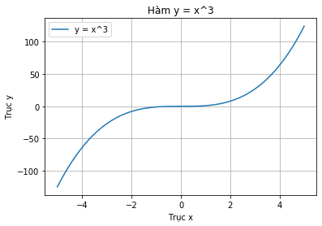

```python
import numpy as np
x = np.arange(-5, 5, 0.01)
y = x ** 3

# Đặt tên
plt.title('Hàm y = x^3')
plt.xlabel('Trục x')
plt.ylabel('Trục y')

# Hiển thị lưới
plt.grid()

# Vẽ plt.plot()
plt.plot(x, y, label='y = x^3')

# HIển thị chú thích
plt.legend()

# Hiển thị hình vẽ
plt.show()
```

Hơn nữa, Matplotlib còn cho chúng ta có thể vẽ nhiều hình trên 1 Figure:

- Chúng ta có thể sử dụng phương thức `.subplot()` gồm có 3 thông số cụ thể:
  - `nrows`: số lượng hàng trên Figure
  - `ncols`: số lượng cột trên Figure
  - `plot_number`: vị trí của plot trong Figure

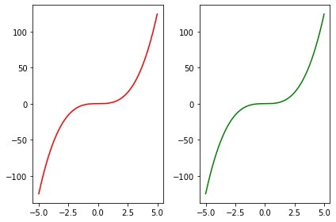

```python
# plt.subplot(nrows, ncols, plot_number)

# nrows = 1, ncols = 2 (1 hàng, 2 cột)
plt.subplot(1, 2, 1) # vẽ ở vị trí 1
plt.plot(x, y, 'red')

plt.subplot(1, 2, 2) # vẽ ở vị trí 2
plt.plot(x, y, 'green')

# Để tránh trường hợp các giá trị trục y của Subplot bên phải nằm sát với Subplot bên trái,
# ta có thể sử dụng phương thức tight_layout()
plt.tight_layout()
```

### Cách 2: Phương thức hướng đối tượng

### Figure

Như đã nói ở trên, thành phần chính của **figure** là các **axes**. Một **figure** có thể chứa một hoặc nhiều **axes**. Hay nói cách khác, **figure** chỉ là khung chứa, chính xác **axes** mới thật sự là nơi các hình được vẽ lên.

Như vậy, sẽ **không có** những cách gọi kiểu như:

```
- f̶̶i̶̶g̶̶.̶̶p̶̶l̶̶o̶̶t̶̶(̶)
- f̶̶i̶̶g̶̶.̶̶x̶̶l̶̶a̶̶b̶̶e̶̶l̶̶(̶)
- ...
```

```python
# Khởi tạo figure trống
fig = plt.figure()

# Hiển thị figure hiện tại
plt.show()
```

Bây giờ chúng ta cần thêm các **axes** vào **figure**, bằng phương thức: `.add_axes()` gồm 4 đối số: `bên trái, phía dưới, chiều rộng, chiều cao.`

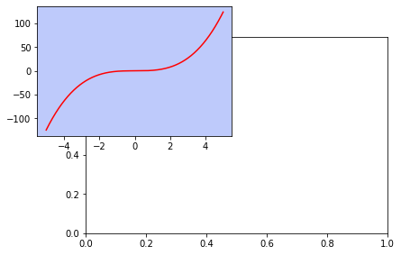

```python
fig = plt.figure()

# Có thể gọi tắt subplot(1,1,1) thành subplot(111)
fig.add_subplot(111)

# facecolor là màu nền
ax = fig.add_axes([0, 0.5, 0.5, 0.5], facecolor='#BECAFB')
ax.plot(x, y, 'red')

plt.show()
```

Thêm tiêu đề cho các axes bằng cách:

- `.set_xlabel()`: tiêu đề trục x
- `.set_ylabel()`: tiêu đề trục y
- `.set_title()`: tiêu đề axes

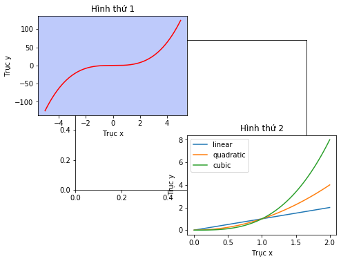

```python
fig = plt.figure()

# Có thể gọi tắt subplot(1,1,1) thành subplot(111)
fig.add_subplot(111)

ax = fig.add_axes([0, 0.5, 0.5, 0.5], facecolor='#BECAFB')
ax.plot(x, y, 'red')

ax.set_xlabel('Trục x')
ax.set_ylabel('Trục y')
ax.set_title('Hình thứ 1')

# Tạo thêm 1 axes trong cùng 1 figure
ax2 = fig.add_axes([0.5, -0.1, 0.5, 0.5])

x = np.linspace(0, 2, 100)
ax2.plot(x, x, label='linear')
ax2.plot(x, x**2, label='quadratic')
ax2.plot(x, x**3, label='cubic')

ax2.set_xlabel('Trục x')
ax2.set_ylabel('Trục y')
ax2.set_title('Hình thứ 2')
ax2.legend()

plt.show()
```

### Một số thuộc tính khác của Figure

1. Chỉnh kích thước của Figure bằng phương thức `figsize` (đơn vị inch).
2. `dpi` độ phân giải của hình, giá trị mặc định là 100. `dpi` càng cao thì chất lượng ảnh càng cao.
3. Lưu Figure bằng `fig.savefig()`

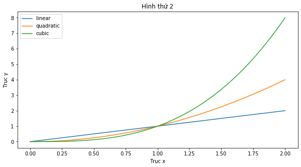

```python
# Khởi tạo nhanh Figure và Axes -> plt.subplots()
fig, ax = plt.subplots(figsize=(10,5))

x = np.linspace(0, 2, 100)
ax.plot(x, x, label='linear')
ax.plot(x, x**2, label='quadratic')
ax.plot(x, x**3, label='cubic')

ax.set_xlabel('Trục x')
ax.set_ylabel('Trục y')
ax.set_title('Hình thứ 2')
ax.legend()

plt.show()

# Lưu figure cùng thư mục với code
fig.savefig('my_figure.png')
```

1. Kiểm tra Figure đã lưu hay chưa?

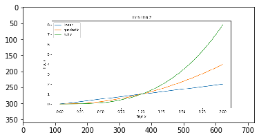

```python
import matplotlib.image as mpimg

# Hiển thị hình ảnh lưu trong máy
plt.imshow(mpimg.imread('my_figure.png'))
```

1. Cách xoá, đóng 1 figure:
   - Xoá nội dung của fig:
     - `fig.clf()`
     - `plt.clf()`
   - Đóng fig:
     - `plt.close(<Tên fig>)`

## Chỉnh trục toạ độ trong Figure ( Spines và Ticks của đồ thị )

Axis spine - đường ghi nhận ranh giới khu vực dữ liệu. Spine là đường kết nối các dấu ticks trên trục và ghi nhận ranh giới của khu vực dữ liệu. Chúng ta có thể cài đặt tuỳ ý.

Ví dụ: khảo sát và vẽ đồ thị hàm số y = sin(x)

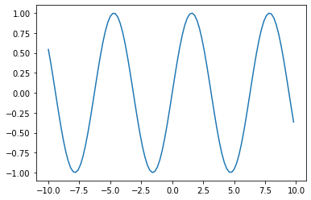

```python
# Trong trường hợp chưa chỉnh các trục toạ độ
x = np.arange(-10., 10., 0.2)
y = np.sin(x)

plt.plot(x, y)
plt.show()
```

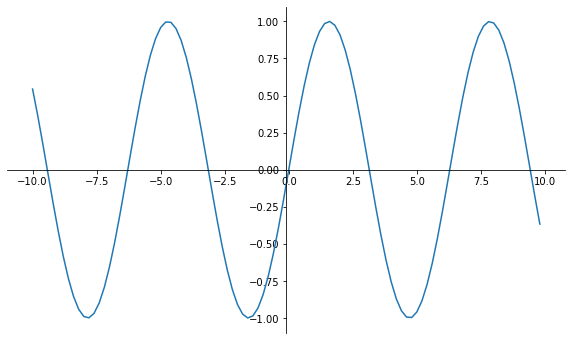

```python
# Chỉnh lại trục toạ độ

fig, ax = plt.subplots(figsize=(10,6))
x = np.arange(-10., 10., 0.2)
y = np.sin(x)

# Biến đường biên bên trên và bên phải -> vô hình
ax.spines['top'].set_color('none')
ax.spines['right'].set_color('none')

# Di chuyển đường bên dưới vào giữa  & ở vị trí y = 0
ax.xaxis.set_ticks_position('bottom')
ax.spines['bottom'].set_position(('data',0))

# Di chuyển đường bên trái vào giữa & ở vị trí x = 0
ax.yaxis.set_ticks_position('left')
# ax.spines['left'].set_position(('data', 0))

# Hoặc thay ('data', 0) thành 'center'
ax.spines['left'].set_position('center')

ax.plot(x, y)
plt.show()
```

### Vẽ đồ thị kiểu điểm

Trong nhiều trường hợp, ta muốn hiển thị từng điểm thay vì đường thẳng, việc chuyển đường thẳng sang điểm chúng ta sử dụng thêm các `marker` trong `.plot()`.

Các `marker` thông dụng:

[figure not shown]

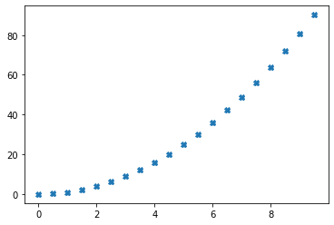

```python
t = np.arange(0., 10., 0.5)

plt.plot(t, t**2, 'X')
plt.show()
```

Cách vẽ vừa điểm, vừa đường:

- Cách 1: nối các điểm bằng đường

Một số kiểu `linestyle`:

[figure not shown]

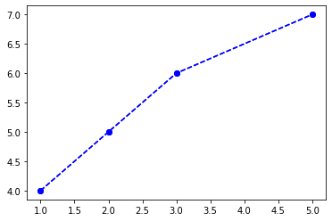

```python
x = [1, 2, 3, 5]
y = [4, 5, 6, 7]

plt.plot(x, y, linestyle='--', marker='o', color='b')

# Một cách ngắn hơn
plt.plot(x, y, '--bo')
plt.show()
```

- Cách 2: Vẽ một vài điểm trên đường

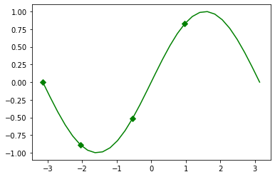

```python
x = np.linspace(-np.pi, np.pi, 30)
y = np.sin(x)
markers_on = [0, 19, 12, 5]
plt.plot(x, y, '-gD', markevery=markers_on)
plt.show()
```

## Bảng tổng kết

- Download file PDF [Tại Đây](https://github.com/thanhhff/AIVN-Machine-Learning/blob/master/Week%203/Matplotlib_Cheat_Sheet.pdf) - Nguồn: DataCamp.com

[figure not shown]

## Tài liệu tham khảo

[1] [Matplotlib User's Guide](https://matplotlib.org/3.1.1/users/index.html)

[2] [Introduction to Matplotlib — Data Visualization in Python by Ehi Aigiomawu](https://heartbeat.fritz.ai/introduction-to-matplotlib-data-visualization-in-python-d9143287ae39)

[3] [Matplotlib: Những điều cần biết để tùy chỉnh Figure như ý muốn](https://texmath.com/matplotlib-nhung-lenh-can-biet-de-tuy-chinh-figure-nhu-y-muon/)